# Training a Neural Network using Augmentor and Keras

## Import Required Libraries

We start by making a number of imports:

```python
import Augmentor

import tensorflow.keras
from tensorflow.keras.models import Sequential
from tensorflow.keras.layers import Dense, Dropout, Flatten
from tensorflow.keras.layers import Conv2D, MaxPooling2D

import numpy as np

import matplotlib.pyplot as plt
%matplotlib inline
```

## Define a Convolutional Neural Network

Once the libraries have been imported, we define a small convolutional neural network. See the Keras documentation for details of this network: https://github.com/fchollet/keras/blob/master/examples/mnist_cnn.py

```python
num_classes = 10
input_shape = (28, 28, 1)

model = Sequential()
model.add(Conv2D(32, kernel_size=(3, 3),
                 activation='relu',
                 input_shape=input_shape))
model.add(Conv2D(64, (3, 3), activation='relu'))
model.add(MaxPooling2D(pool_size=(2, 2)))
model.add(Dropout(0.25))
model.add(Flatten())
model.add(Dense(128, activation='relu'))
model.add(Dropout(0.5))
model.add(Dense(num_classes, activation='softmax'))
```

Once a network has been defined, you can compile it so that the model is ready to be trained with data:

```python
model.compile(loss=tensorflow.keras.losses.categorical_crossentropy,
              optimizer=tensorflow.keras.optimizers.Adadelta(),
              metrics=['accuracy'])
```

You can view a summary of the network using the `summary()` function:

```python
model.summary()
```

```
Model: "sequential"
_________________________________________________________________
Layer (type)                 Output Shape              Param #
=================================================================
conv2d (Conv2D)              (None, 26, 26, 32)        320
_________________________________________________________________
conv2d_1 (Conv2D)            (None, 24, 24, 64)        18496
_________________________________________________________________
max_pooling2d (MaxPooling2D) (None, 12, 12, 64)        0
_________________________________________________________________
dropout (Dropout)            (None, 12, 12, 64)        0
_________________________________________________________________
flatten (Flatten)            (None, 9216)              0
_________________________________________________________________
dense (Dense)                (None, 128)               1179776
_________________________________________________________________
dropout_1 (Dropout)          (None, 128)               0
_________________________________________________________________
dense_1 (Dense)              (None, 10)                1290
=================================================================
Total params: 1,199,882
Trainable params: 1,199,882
Non-trainable params: 0
_________________________________________________________________
```

## Use Augmentor to Scan Directory for Data

Now we will use Augmentor to scan a directory containing our data that we will eventually feed into the neural network in order to train it.

When you point a pipeline to a directory, it will scan each subdirectory and treat each subdirectory as a class for your machine learning problem.

For example, within the directory `mnist`, there are subdirectories for each digit:

```
mnist/
├── 0/
│   ├── 0001.png
│   ├── 0002.png
│   ├── ...
│   └── 5985.png
├── 1/
│   ├── 0001.png
│   ├── 0002.png
│   ├── ...
│   └── 6101.png
├── 2/
│   ├── 0000.png
│   ├── 0001.png
│   ├── ...
│   └── 5801.png
│ ...
├── 9/
│   ├── 0001.png
│   ├── 0002.png
│   ├── ...
│   └── 6001.png
└
```

The directory `0` contains all the images corresponding to the 0 class.

To get the data, we can use `wget` (this may not work under Windows):

```python
![[ -f ./seed_images_Kannada.npy ]] || wget https://github.com/unifyid-labs/DeepGenStruct-Notebooks/raw/master/seed/seed_images_Kannada.npy
!mkdir -p images/{0..9}
from PIL import Image
img = np.load("./seed_images_Kannada.npy")
for i in range(10):
	print(img.shape)
	for j in range(img[i].size//28):
		Image.fromarray(img[i].astype(np.uint8)).save("./images/"+str(i)+"/"+str(i)+".png")
```

```
(10, 28, 28)
(10, 28, 28)
(10, 28, 28)
(10, 28, 28)
(10, 28, 28)
(10, 28, 28)
(10, 28, 28)
(10, 28, 28)
(10, 28, 28)
(10, 28, 28)
```

```python
p = Augmentor.Pipeline("images/")
```

```
Initialised with 10 image(s) found.
Output directory set to images/output.
```

## Add Operations to the Pipeline

Now that a pipeline object `p` has been created, we can add operations to the pipeline. Below we add several simple operations:

```python
p.flip_top_bottom(probability=0.1)
p.rotate(probability=0.3, max_left_rotation=5, max_right_rotation=5)
```

You can view the status of pipeline using the `status()` function, which shows information regarding the number of classes in the pipeline, the number of images, and what operations have been added to the pipeline:

```python
p.status()
```

```
Operations: 2
	0: Flip (probability=0.1 top_bottom_left_right=TOP_BOTTOM )
	1: RotateRange (probability=0.3 max_left_rotation=-5 max_right_rotation=5 )
Images: 10
Classes: 10
	Class index: 0 Class label: 0
	Class index: 1 Class label: 1
	Class index: 2 Class label: 2
	Class index: 3 Class label: 3
	Class index: 4 Class label: 4
	Class index: 5 Class label: 5
	Class index: 6 Class label: 6
	Class index: 7 Class label: 7
	Class index: 8 Class label: 8
	Class index: 9 Class label: 9
Dimensions: 1
	Width: 28 Height: 28
Formats: 1
	 PNG

You can remove operations using the appropriate index and the remove_operation(index) function.
```

## Creating a Generator

A generator will create images indefinitely, and we can use this generator as input into the model created above. The generator is created with a user-defined batch size, which we define here in a variable named `batch_size`. This is used later to define number of steps per epoch, so it is best to keep it stored as a variable.

```python
batch_size = 128
g = p.keras_generator(batch_size=batch_size)
```

The generator can now be used to created augmented data. In Python, generators are invoked using the `next()` function - the Augmentor generators will return images indefinitely, and so `next()` can be called as often as required.

You can view the output of generator manually:

```python
images, labels = next(g)
```

To see the label of the first image returned by the generator you can use the array's index:

```python
print(labels[0])
```

```
[0 0 0 0 0 0 0 0 0 1]
```

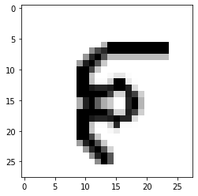

```python
plt.imshow(images[0].reshape(28, 28), cmap="Greys");
```

## Train the Network

We train the network by passing the generator, `g`, to the model's fit function. In Keras, if a generator is used we used the `fit_generator()` function as opposed to the standard `fit()` function. Also, the steps per epoch should roughly equal the total number of images in your dataset divided by the `batch_size`.

```python
h = model.fit_generator(g, steps_per_epoch=len(p.augmentor_images)/batch_size, epochs=5, verbose=1)
```

[output not shown]

## Summary

Using Augmentor with Keras means only that you need to create a generator when you are finished creating your pipeline. This has the advantage that no images need to be saved to disk and are augmented on the fly.